# **Aplicaciones de los Modelos Supervisados Predictivos**

**Basado en el proyecto del Módulo 3 Bootcamp de Ciencia de Datos e Inteligencia Artificial**

## Introducción

Descarga el archivo de la siguiente liga: https://drive.google.com/file/d/1mwbTl_m-r6oyKVl_ZHPOE4Io5tMohkr1/view?usp=sharing

Un equipo de Recursos Humanos te acaba de proporcionar el archivo que has descargado. En este se indican algunas características que ellos creen que influyen en el salario que buscan algunas personas que se postulan en empresas de tecnología.

Este equipo pide de tu apoyo para diseñar un modelo que pueda predecir cuánto pedirá cada postulante con base en las siguientes características:

- `Experiencia`: Años de experiencia en el área.
- `Posición`: Posición que busca; existen tres opciones:
  - `Analista`
  - `Coordinador`
  - `Gerente`
- `Hijos`: Número de hijos que tiene.
- `Casado`: ¿El postulante está casado?
  - `0`: No
  - `1`: Sí
- `Educación`: ¿Cuál es el grado máximo de estudios concluido? Existen tres opciones:
  - `Bachillerato`
  - `Licenciatura`
  - `Posgrado`
- `Salario`: Cantidad en pesos mexicanos que pide. Esta variable es la que se pretende predecir en este ejercicio.

## Modelo Predictivo de Salarios en el Sector Tecnológico

### Análisis Exploratorio

#### Análisis exploratorio

```
El número de filas en el dataframe es: 1000

El número de variables en el dataframe es: 6

   Experiencia     Posicion  Hijos  Casado     Educacion  Salario
0          0.5     Analista      4       1  Bachillerato    13540
1          5.6     Analista      2       0  Licenciatura    31240
2         11.7     Analista      1       0  Licenciatura    63880
3          5.2     Analista      2       1  Licenciatura    29960
4          7.2  Coordinador      2       1  Licenciatura    34710

Variables continuas y discretas:

       Experiencia        Hijos       Casado       Salario
count  1000.000000  1000.000000  1000.000000   1000.000000
mean      6.416200     1.453000     0.595000  30787.060000
std       2.577612     1.208823     0.491138  11520.200049
min       0.100000     0.000000     0.000000   5630.000000
25%       4.600000     0.000000     0.000000  22557.500000
50%       6.400000     1.000000     1.000000  29470.000000
75%       8.100000     2.000000     1.000000  37922.500000
max      15.200000     4.000000     1.000000  83470.000000

Variables cualitativas o categóricas:

Analista       790
Coordinador    151
Gerente         59
Name: Posicion, dtype: int64

Bachillerato    531
Licenciatura    369
Posgrado        100
Name: Educacion, dtype: int64
```

#### Análisis de completitud

|  | Nombre | Total | Completitud |
| --- | --- | --- | --- |
| 0 | Experiencia | 0 | 100.0 |
| 1 | Posicion | 0 | 100.0 |
| 2 | Hijos | 0 | 100.0 |
| 3 | Casado | 0 | 100.0 |
| 4 | Educacion | 0 | 100.0 |
| 5 | Salario | 0 | 100.0 |

No hay valores faltantes en el dataframe, pero es necesario revisar la presencia de valores atípicos.

#### Análisis de outliers

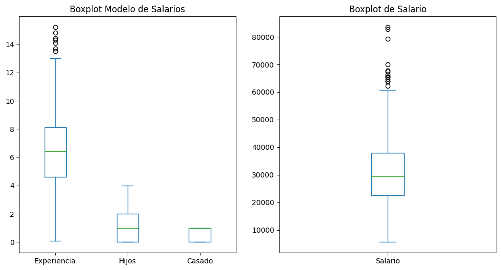

Como puede verse, hay algunos valores atípicos en `Experiencia` y `Salario`, por lo que pueden distorsionar los efectos del modelo debido al peso o influencia que pueden tener. Sin embargo, el eliminarlos, teniendo en cuenta que no se deben a un error de muestreo o de la construcción de la base, puede llevar a pérdida de información y capacidad de inferencia en el modelo ya que se elimina parte de la variabilidad que puede ser explicada por el componente estocástico $\epsilon$ o el conjunto de variables independientes $X$.

En lugar de eliminarlos, se pueden realizar medidas para reducir el peso o influencia de estos, como la estandarización o escalamiento de los datos, además del utilizar medidas robustas a estos, como la mediana.

#### Análisis gráfico

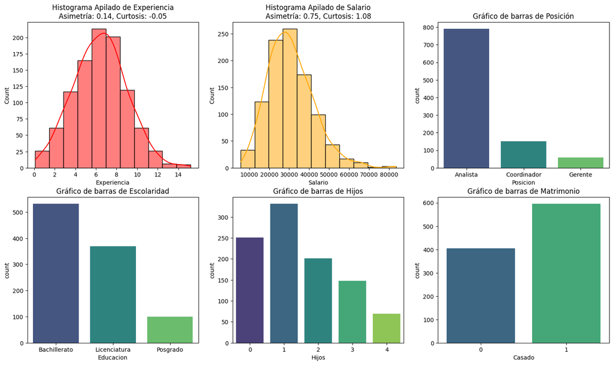

Como se puede observar, los años de experiencia se distribuyen de manera casi uniforme respecto a la media (Asimetría = 0.14), teniendo una curva asimétrica positiva y, al mismo tiempo, la concentración de valores es casi mesocúrtica (Curtosis = -0.05). En este caso, se puede ver que que la mayoría de aspirantes (alrededor de 400) tienen entre 6 y 8 años de experiencia.

Por otro lado, las aspiraciones salariales están en su mayoría (más de 600)entre 20.000 y 40.000, teniendo su concentración en 30.000, por lo que es leptocúrtica (Curtosis = 1.08), mientras que su curva de asimetría es positiva, lo cual es entendible ya que los valores no pueden ser negativos.

Frente a la cantidad de hijos y el estado civil, se puede observar que la mayoría de aspirantes (más de 300) tienen 1 hijo, sin embargo, 250 (aproximadamente un cuarto de la muestra) no tiene hijos. Además, cerca de 600 aspirantes están casados o casadas, lo que podría relacionarse con que tres cuartos de los aspirantes tienen al menos 1 hijo.

Por último, gran parte de los y las aspirantes apuntan al puesto de Analista (casi 800); al contrario, muy pocos apuntan a los puestos de Coordinador o de Gerente. Con esto dicho, más de 500 participantes solo tienen el bachillerato, mientras que alrededor de 100 tienen un posgrado.

```
                               Salario  Experiencia
Educacion    Posicion
Bachillerato Analista     27353.884120     6.379614
             Coordinador  31730.600000     6.410000
             Gerente      46378.000000     6.493333
Licenciatura Analista     29978.827839     6.449817
             Coordinador  36478.181818     6.781818
             Gerente      50780.666667     6.490000
Posgrado     Analista     32496.274510     6.062745
             Coordinador  37660.857143     6.657143
             Gerente      47665.000000     5.721429
```

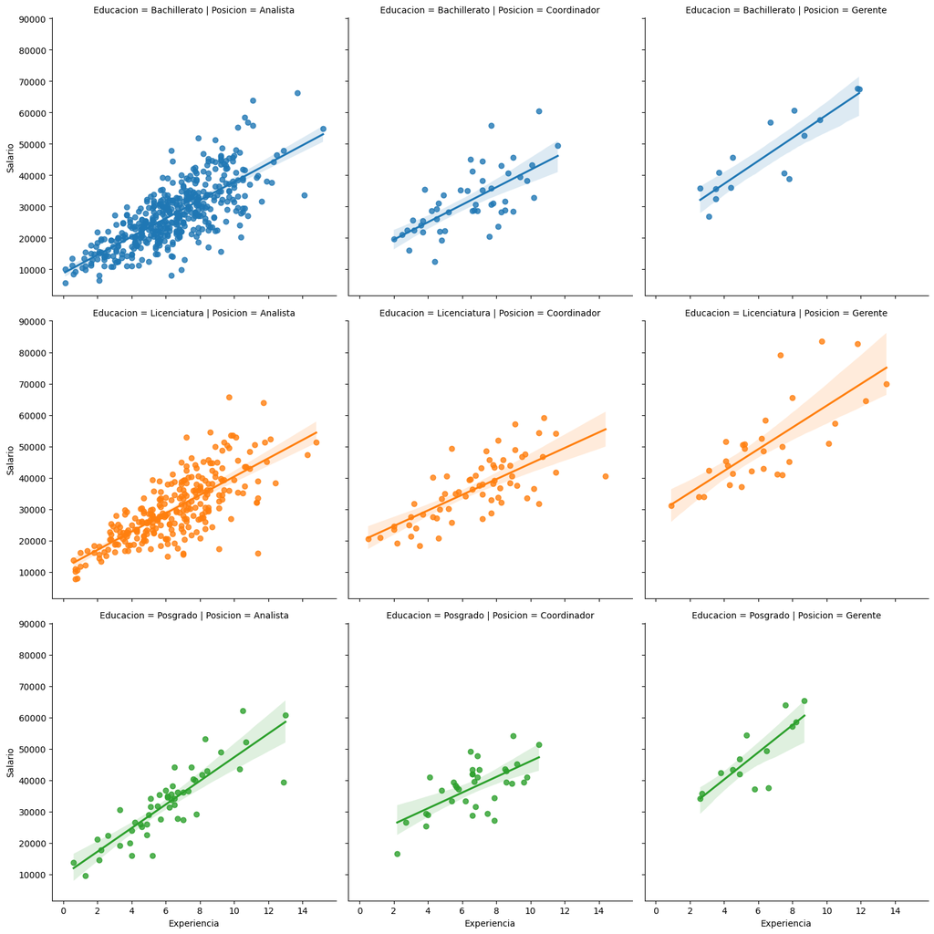

En conclusión, la cantidad de aspirantes tiende a disminuir a medida que el cargo aumenta de jerarquía, probablemente por la cantidad de vacantes disponibles. Asimismo, las expectativas salariales son mayores en las personas con posgrados, excepto en el puesto de Gerente, dado que ahí son los licenciados quienes mayores expectativas salariales tienen, mientras que los de posgrado tienen en promedio menos años de experiencia.

#### Análisis de correlación

|  | Salario |
| --- | --- |
| Salario | 1.000000 |
| Experiencia | 0.663780 |
| Hijos | 0.211630 |
| Casado | 0.085462 |

|  | Experiencia | Hijos | Casado | Salario |
| --- | --- | --- | --- | --- |
| Experiencia | 1.000000 | -0.001522 | 0.002578 | 0.663780 |
| Hijos | -0.001522 | 1.000000 | 0.327876 | 0.211630 |
| Casado | 0.002578 | 0.327876 | 1.000000 | 0.085462 |
| Salario | 0.663780 | 0.211630 | 0.085462 | 1.000000 |

El Análisis de correlación señala que, desde un enfoque univaridado respecto a `Salario`, este solo tiene una alta correlación positiva con `Experiencia`, mientras que las otras dos variables tienen una mínima correlación positiva.

Desde el análisis multivariado, se confirma que `Experiencia` y `Salario` son la única pareja que tiene una correlación lineal alta, lo que puede implicar un problema de multicolinealidad al ajustar el modelo.

### Entrenamiento del modelo

#### Codificación de variables categóricas

|  | Experiencia | Hijos | Casado | Salario | edu_Bachillerato | edu_Licenciatura | edu_Posgrado | pos_Analista | pos_Coordinador | pos_Gerente |
| --- | --- | --- | --- | --- | --- | --- | --- | --- | --- | --- |
| 0 | 0.5 | 4 | 1 | 13540 | 1 | 0 | 0 | 1 | 0 | 0 |
| 1 | 5.6 | 2 | 0 | 31240 | 0 | 1 | 0 | 1 | 0 | 0 |
| 2 | 11.7 | 1 | 0 | 63880 | 0 | 1 | 0 | 1 | 0 | 0 |
| 3 | 5.2 | 2 | 1 | 29960 | 0 | 1 | 0 | 1 | 0 | 0 |
| 4 | 7.2 | 2 | 1 | 34710 | 0 | 1 | 0 | 0 | 1 | 0 |

#### Estandarización de las variables

```
El tamaño de X es (1000, 9) y de y es (1000,).

El conjunto de variables independientes es:

      Experiencia  Hijos  Casado  edu_Bachillerato  edu_Licenciatura  \
0            0.5      4       1                 1                 0
1            5.6      2       0                 0                 1
2           11.7      1       0                 0                 1
3            5.2      2       1                 0                 1
4            7.2      2       1                 0                 1
..           ...    ...     ...               ...               ...
995          6.0      2       1                 1                 0
996          6.9      1       0                 0                 1
997         11.4      0       0                 0                 1
998          9.9      2       1                 1                 0
999         10.2      3       1                 1                 0

     edu_Posgrado  pos_Analista  pos_Coordinador  pos_Gerente
0               0             1                0            0
1               0             1                0            0
2               0             1                0            0
3               0             1                0            0
4               0             0                1            0
..            ...           ...              ...          ...
995             0             1                0            0
996             0             1                0            0
997             0             1                0            0
998             0             1                0            0
999             0             1                0            0

[1000 rows x 9 columns]

La variable dependiente es:

 0      13540
1      31240
2      63880
3      29960
4      34710
       ...
995    21820
996    34010
997    38840
998    45660
999    55210
Name: Salario, Length: 1000, dtype: int64
```

#### Conjuntos de entrenamiento y de prueba

#### Entrenamiento del modelo

```
LinearRegression()
```

|  | Realidad | Predicción | Residuos |
| --- | --- | --- | --- |
| 0 | 27910 | 29631.991272 | -1721.991272 |
| 1 | 42430 | 30349.991272 | 12080.008728 |
| 2 | 29670 | 30939.991272 | -1269.991272 |
| 3 | 45270 | 30793.991272 | 14476.008728 |
| 4 | 38630 | 36435.991272 | 2194.008728 |

```
((300, 1), (300, 1))
```

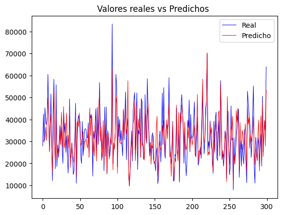

```
Los parámetros del modelo son: intercepto=[30737.65], coeficientes=[[ 7.61288800e+03  2.33296700e+03 -5.86500000e+00  2.91296025e+15
   2.81662312e+15  1.75114509e+15  4.80526973e+16  4.22412631e+16
   2.77981181e+16]]
```

```
El Coeficiente de determinación del modelo es: 68.95%

El Error absoluto medio es: 5150.89

El Error cuadrático medio es: 43494978.000220

La Raíz del error cuadrático medio es: 6595.07
```

El intercepto de 30737.65 representa la estimación de la aspiración salarial sin la influencia de las demás variables independientes o, en otras palabras, cuando todas las variables del conjunto $X$ son cero. El coeficiente positivo para la variable `Experiencia` indica que, manteniendo constantes las demás variables, un aumento en 1 año de experiencia se asocia con un aumento en el valor predicho de la aspiración salarial. Además, el coeficiente positivo para `Hijos` sugiere que un mayor número de hijos está relacionado con un aumento en las aspiraciones salariales. Sin embargo, el coeficiente negativo para `Casado` implica que estar casado se asocia con una disminución en las aspiraciones salariales.

Por otro lado, el coeficiente de determinación indica que la varianza explicada por el modelo es de un 68.95%, implicando que hay una no despreciable variación explicada por el componente estocástico $\epsilon$, lo que indica que hay una serie de variables ocultas que influyen en las aspiraciones salariales.

#### Test de supuestos estadísticos

```
Supuesto de Linealidad
Media de los residuos: 157.40559210625287

Supuesto de Homocedasticidad
Estadística de Breusch-Pagan: 79.269, Valor p: 0.000000000000226

Supuesto de Autocorrelación
Estadística de Durbin-Watson: 1.847

Supuesto de Normalidad
Estadística de Shapiro-Wilk: 0.995, Valor p: 0.486

Supuesto de Multicolinealidad
Factor de Inflación de la Varianza
const: 0.000
Experiencia: 2.443
Hijos: 1.252
Casado: 1.125
Salario: 3.272
edu_Bachillerato: inf
edu_Licenciatura: inf
edu_Posgrado: inf
pos_Analista: inf
pos_Coordinador: inf
pos_Gerente: inf
```

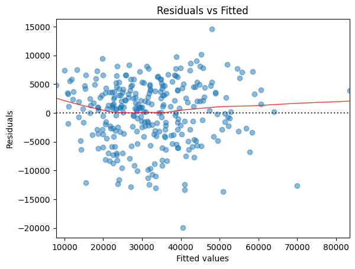

#### Aplicación de regularizadores

##### Regularizador Lasso (L1)

$$ L = \sum_{i=1}^N (y_i - \hat{y}_i )^2 + \alpha \sum_{i=1}^N |b_i| $$

```
LassoCV(alphas=array([1.00000000e-07, 1.17584955e-07, 1.38262217e-07, 1.62575567e-07,
       1.91164408e-07, 2.24780583e-07, 2.64308149e-07, 3.10786619e-07,
       3.65438307e-07, 4.29700470e-07, 5.05263107e-07, 5.94113398e-07,
       6.98587975e-07, 8.21434358e-07, 9.65883224e-07, 1.13573336e-06,
       1.33545156e-06, 1.57029012e-06, 1.84642494e-06, 2.17111795e-06,
       2.55290807e-06, 3.00183581e-0...
       2.40940356e+05, 2.83309610e+05, 3.33129479e+05, 3.91710149e+05,
       4.60592204e+05, 5.41587138e+05, 6.36824994e+05, 7.48810386e+05,
       8.80488358e+05, 1.03532184e+06, 1.21738273e+06, 1.43145894e+06,
       1.68318035e+06, 1.97916687e+06, 2.32720248e+06, 2.73644000e+06,
       3.21764175e+06, 3.78346262e+06, 4.44878283e+06, 5.23109931e+06,
       6.15098579e+06, 7.23263390e+06, 8.50448934e+06, 1.00000000e+07]),
        cv=5)
```

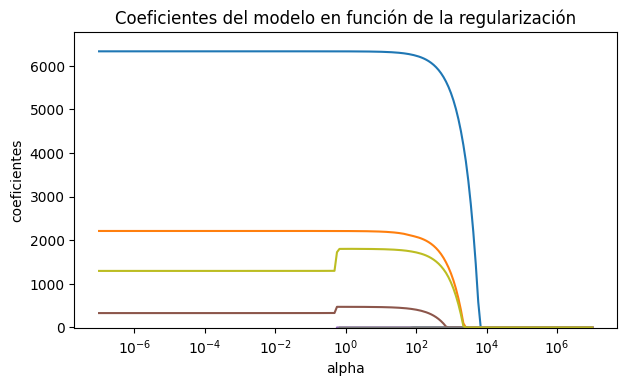

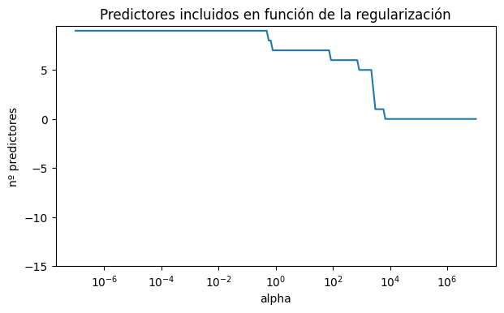

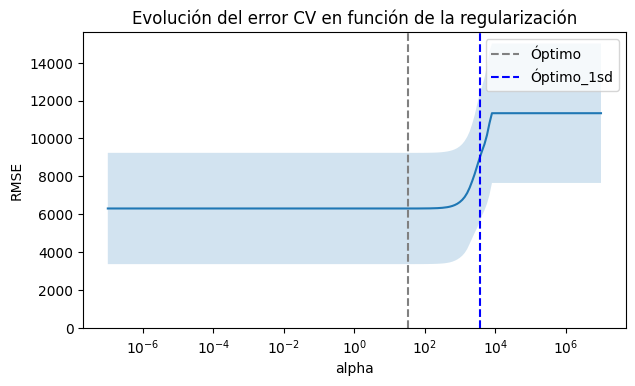

```
El mejor parametro de alpha es: 32.550885998350566
```

```
Mejor valor de alpha encontrado + 1 desviación estándar: [3570.7859649]
```

```
Lasso(alpha=3570.7859649004554)
```

|  | predictor | coef |
| --- | --- | --- |
| 0 | Experiencia | 4091.968714 |
| 6 | pos_Analista | -146.708857 |
| 8 | pos_Gerente | 201.425581 |

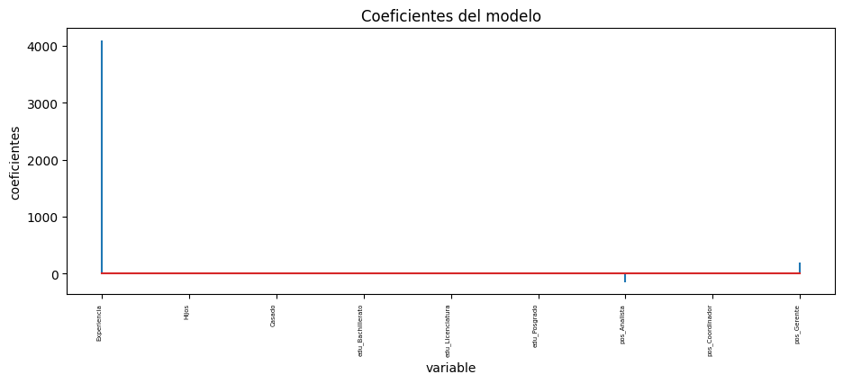

|  | Realidad | Predicción | Residuos | Lasso |
| --- | --- | --- | --- | --- |
| 0 | 27910 | 29631.991272 | -1721.991272 | 29617.971953 |
| 1 | 42430 | 30349.991272 | 12080.008728 | 30380.880102 |
| 2 | 29670 | 30939.991272 | -1269.991272 | 30950.529246 |
| 3 | 45270 | 30793.991272 | 14476.008728 | 30830.765624 |
| 4 | 38630 | 36435.991272 | 2194.008728 | 36368.022929 |

```
El error cuadrático medio de test es: 6597.562760730914
```

El regularizador Lasso minimiza la suma de los errores cuadráticos mediante la suma del valor absoluto de los coeficientes por un término de regularización, lo que tiende a establecer algunos coeficientes a cero, como puede verse que solo tres de los predictores tienen un coeficiente distinto de cero, que son `Experiencia`, `pos_Analista` y `pos_Gerente`.

##### Regularizador Ridge (L2)

$$ L = \sum_{i=1}^N (y_i - \hat{y}_i )^2 + \alpha \sum_{i=1}^N b_i^2 $$

```
RidgeCV(alphas=array([1.00000000e-10, 1.21738273e-10, 1.48202071e-10, 1.80418641e-10,
       2.19638537e-10, 2.67384162e-10, 3.25508860e-10, 3.96268864e-10,
       4.82410870e-10, 5.87278661e-10, 7.14942899e-10, 8.70359136e-10,
       1.05956018e-09, 1.28989026e-09, 1.57029012e-09, 1.91164408e-09,
       2.32720248e-09, 2.83309610e-09, 3.44896226e-09, 4.19870708e-09,
       5.11143348e-09, 6.22257084e-0...
       1.08436597e+05, 1.32008840e+05, 1.60705282e+05, 1.95639834e+05,
       2.38168555e+05, 2.89942285e+05, 3.52970730e+05, 4.29700470e+05,
       5.23109931e+05, 6.36824994e+05, 7.75259749e+05, 9.43787828e+05,
       1.14895100e+06, 1.39871310e+06, 1.70276917e+06, 2.07292178e+06,
       2.52353917e+06, 3.07211300e+06, 3.73993730e+06, 4.55293507e+06,
       5.54266452e+06, 6.74754405e+06, 8.21434358e+06, 1.00000000e+07]),
        store_cv_values=True)
```

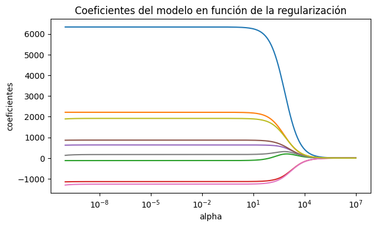

```
El mejor parámetro para alpha es: 3.2176417502507353
```

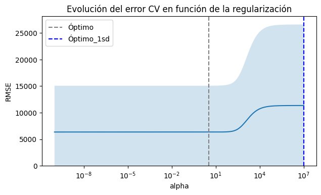

```
RidgeCV(alphas=3.2176417502507353, store_cv_values=True)
```

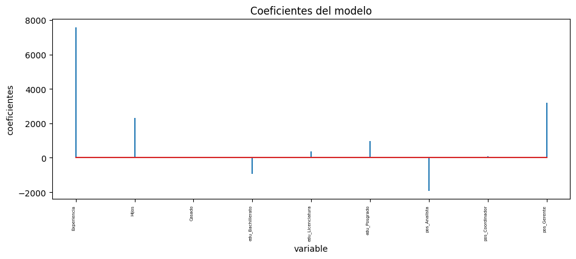

|  | Realidad | Predicción | Residuos | Lasso | Ridge |
| --- | --- | --- | --- | --- | --- |
| 0 | 27910 | 29631.991272 | -1721.991272 | 29617.971953 | 29641.496756 |
| 1 | 42430 | 30349.991272 | 12080.008728 | 30380.880102 | 30335.361950 |
| 2 | 29670 | 30939.991272 | -1269.991272 | 30950.529246 | 30941.008976 |
| 3 | 45270 | 30793.991272 | 14476.008728 | 30830.765624 | 30778.332189 |
| 4 | 38630 | 36435.991272 | 2194.008728 | 36368.022929 | 36415.334601 |

```
El error cuadrático medio de test es: 6596.123561050188
```

El regularizador Ridge tiene como objetivo minimizar la suma de los errores cuadráticos junto con la suma de los cuadrados de los coeficientes por el término de regularización.

El efecto que tiene es tender los coeficientes hacia cero sin alcanzarlo exactamente, con el fin de reducir la magnitud de los coeficientes cuando se sospecha problemas de colinealidad.

##### Regularizador ElasticNet (L1 y L2)

$$ \sum_{i=1}^{n} (y_i - f(x_i))^2 + \alpha (\lambda \sum_{j=1}^{p} \beta^2 + (1-\lambda) \sum_{j=1}^{p} |\beta_j| $$

```
ElasticNetCV(alphas=array([1.00000000e-07, 1.08005237e-07, 1.16651313e-07, 1.25989528e-07,
       1.36075289e-07, 1.46968439e-07, 1.58733611e-07, 1.71440614e-07,
       1.85164842e-07, 1.99987727e-07, 2.15997219e-07, 2.33288310e-07,
       2.51963593e-07, 2.72133877e-07, 2.93918840e-07, 3.17447741e-07,
       3.42860186e-07, 3.70306958e-07, 3.99950910e-07, 4.31967930e-07,
       4.66547988e-07, 5.038962...
       1.70125428e+02, 1.83744372e+02, 1.98453546e+02, 2.14340223e+02,
       2.31498667e+02, 2.50030685e+02, 2.70046235e+02, 2.91664078e+02,
       3.15012480e+02, 3.40229977e+02, 3.67466194e+02, 3.96882735e+02,
       4.28654141e+02, 4.62968923e+02, 5.00030684e+02, 5.40059328e+02,
       5.83292359e+02, 6.29986298e+02, 6.80418197e+02, 7.34887289e+02,
       7.93716762e+02, 8.57255673e+02, 9.25881025e+02, 1.00000000e+03]),
             cv=5, l1_ratio=[0, 0.1, 0.5, 0.7, 0.9, 0.95, 0.99])
```

|  | l1_ratio | modelo.alphas_ | mse_cv | rmse_cv |
| --- | --- | --- | --- | --- |
| 1919 | 0.99 | 0.104729 | 3.980835e+07 | 6309.385966 |
| 1920 | 0.99 | 0.096967 | 3.980835e+07 | 6309.385971 |
| 1921 | 0.99 | 0.089780 | 3.980835e+07 | 6309.386047 |
| 1918 | 0.99 | 0.113113 | 3.980835e+07 | 6309.386050 |
| 1922 | 0.99 | 0.083125 | 3.980835e+07 | 6309.386178 |
| ... | ... | ... | ... | ... |
| 301 | 0.10 | 925.881025 | 1.281962e+08 | 11322.376689 |
| 2 | 0.00 | 857.255673 | 1.281976e+08 | 11322.438678 |
| 300 | 0.10 | 1000.000000 | 1.282159e+08 | 11323.247527 |
| 1 | 0.00 | 925.881025 | 1.282168e+08 | 11323.285210 |
| 0 | 0.00 | 1000.000000 | 1.282345e+08 | 11324.069230 |

2100 rows × 4 columns

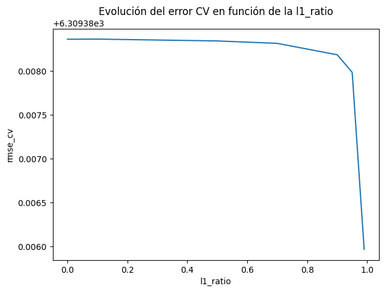

```
Mejor valor de alpha encontrado: 0.10472898382363574
Mejor valor de l1_ratio encontrado: 0.99
```

|  | predictor | coef |
| --- | --- | --- |
| 0 | Experiencia | 7604.284473 |
| 1 | Hijos | 2332.432093 |
| 2 | Casado | -10.302308 |
| 3 | edu_Bachillerato | -1044.866173 |
| 4 | edu_Licenciatura | 275.633417 |
| 5 | edu_Posgrado | 891.534680 |
| 6 | pos_Analista | -2037.449595 |
| 7 | pos_Coordinador | -37.451770 |
| 8 | pos_Gerente | 3140.569337 |

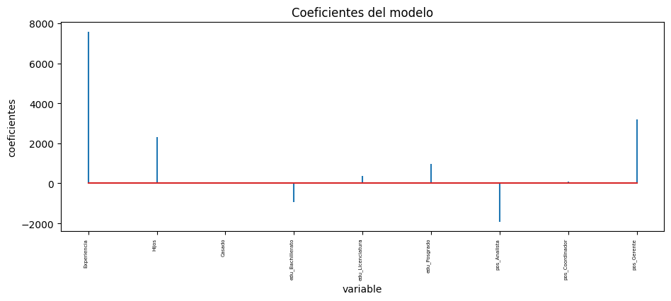

|  | Realidad | Predicción | Residuos | Lasso | Ridge | Elastic |
| --- | --- | --- | --- | --- | --- | --- |
| 0 | 27910 | 29631.991272 | -1721.991272 | 29617.971953 | 29641.496756 | 29643.222728 |
| 1 | 42430 | 30349.991272 | 12080.008728 | 30380.880102 | 30335.361950 | 30339.669580 |
| 2 | 29670 | 30939.991272 | -1269.991272 | 30950.529246 | 30941.008976 | 30938.527806 |
| 3 | 45270 | 30793.991272 | 14476.008728 | 30830.765624 | 30778.332189 | 30791.467201 |
| 4 | 38630 | 36435.991272 | 2194.008728 | 36368.022929 | 36415.334601 | 36434.785521 |

```
El error (rmse) de test es: 6595.254121681504
```

El regularizador ElasticNet tiene como objetivo combinar tanto Lasso (L1) como Ridge (L2) en la función de costo, con el fin de combinar las ventajar de ambos, es decir, reducción de características irrelevantes y colinealidad.

#### Modelo sin outliers

Se pretende revisar la capacidad del modelo eliminando los outliers a pesar de la posible pérdida de información relevante. En este caso, se ve que, como se mencionó anteriomente, solo `Experiencia` y `Salario` tienen outliers y son menos del 2% de cada variable.

|  | columna | outliers IQR | outliers Percentil | outliers cambio promedio | outliers IQR % | outliers Percentil % | outliers cambio promedio % | indices | outliers total | % outliers total |
| --- | --- | --- | --- | --- | --- | --- | --- | --- | --- | --- |
| 0 | Experiencia | 7 | 96 | 3 | 0.7 | 9.6 | 0.3 | [708, 870, 491, 272, 529, 851, 118, 503, 541] | 9 | 0.9 |
| 1 | Hijos | 0 | 0 | 0 | 0.0 | 0.0 | 0.0 | [] | 0 | 0.0 |
| 2 | Casado | 0 | 0 | 0 | 0.0 | 0.0 | 0.0 | [] | 0 | 0.0 |
| 3 | Salario | 15 | 99 | 3 | 1.5 | 9.9 | 0.3 | [545, 2, 870, 910, 335, 272, 943, 530, 915, 21... | 16 | 1.6 |
| 4 | edu_Bachillerato | 0 | 0 | 0 | 0.0 | 0.0 | 0.0 | [] | 0 | 0.0 |
| 5 | edu_Licenciatura | 0 | 0 | 0 | 0.0 | 0.0 | 0.0 | [] | 0 | 0.0 |
| 6 | edu_Posgrado | 100 | 0 | 0 | 10.0 | 0.0 | 0.0 | [] | 0 | 0.0 |
| 7 | pos_Analista | 210 | 0 | 0 | 21.0 | 0.0 | 0.0 | [] | 0 | 0.0 |
| 8 | pos_Coordinador | 151 | 0 | 0 | 15.1 | 0.0 | 0.0 | [] | 0 | 0.0 |
| 9 | pos_Gerente | 59 | 0 | 0 | 5.9 | 0.0 | 0.0 | [] | 0 | 0.0 |

```
(978, 10)
```

```
LinearRegression()
```

|  | Real | Prediccion | Residuo |
| --- | --- | --- | --- |
| 895 | 9950 | 10301.757698 | -351.757698 |
| 222 | 10430 | 10729.757698 | -299.757698 |
| 356 | 7630 | 10953.757698 | -3323.757698 |
| 733 | 10940 | 10953.757698 | -13.757698 |
| 62 | 15010 | 12061.757698 | 2948.242302 |

```
El Coeficiente de determinación del modelo es: 69.49%

El Error absoluto medio es: 4519.39

El Error cuadrático medio es: 35171116.197684

La Raíz del error cuadrático medio es: 5930.52
```

El RMSE resultó siendo mucho menor que el modelo original y las 3 regularizaciones aplicadas, lo que implica que este modelo logra ajustarse mejor a los valores. Sin embargo, la variación explicada por el modelo apenas aumenta respecto al modelo con outliers.

#### Modelo con outliers imputados

Se plantea investigar otro enfoque en el tratamiento de los outliers presentes en el dataset. En este sentido, se imputaran los datos atípicos a partir de la media de las columnas para revisar el efecto que esto tiene en la capacidad predictiva del modelo.

```
(1000, 10)
```

```
LinearRegression()
```

|  | Real | Prediccion | Residuo |
| --- | --- | --- | --- |
| 916 | 9950.0 | 10368.48539 | -418.48539 |
| 58 | 7850.0 | 11408.48539 | -3558.48539 |
| 422 | 13180.0 | 12336.48539 | 843.51461 |
| 700 | 11360.0 | 12992.48539 | -1632.48539 |
| 234 | 11850.0 | 13088.48539 | -1238.48539 |

```
El Coeficiente de determinación del modelo es: 65.77%

El Error absoluto medio es: 5002.21

El Error cuadrático medio es: 41428795.603383

La Raíz del error cuadrático medio es: 6436.52
```

El coeficiente de determinación del modelo indica que 65.77% de la varianza de la aspiración salarial es explicada por el modelo. Con esto dicho, es claro que el modelo con imputación de outliers tiene un menor $R^2$ que sus contrapartes; pero tiene un $RMSE$ menor que el modelo estimado con MCO sin eliminar los outliers, pero sigue quedando atrás del modelo en que se eliminaron. Por lo tanto, se puede afirmar que para este dataset, la eliminación de outliers es el proceso más benéfico para el modelo.

#### Comparación de los modelos

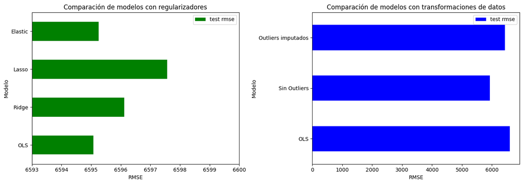

Es por esta razón que probablemente los regularizadores no proporcionarían mejoras significativas, lo que se confirma al evaluar los RMSE de los cuatro modelos, donde persiste la tendencia de que el menor RMSE corresponde al modelo ajustado mediante MCO.

De manera que para este modelo la aplicación de regularizadores no se traduce en beneficios discernibles para la capacidad predictiva. Sin embargo, por los problemas de heterocedasticidad, es recomendable utilizar un método de Mínimos Cuadrados Ponderados (MCP) para solucionar este problema.

[output not shown]